# Multiple-linear regression.

```r
#Adj. R-Squared

#5 value: 0.2548
#X1 & X3- 0.1066
#X2 & X3- 0.2493
#X3 & X4- 0.2351
#X3 & X5- 0.2529 *
#X3 & X6- 0.2058

#X1 & X2- 0.1043
#X1 & X4- 0.07933
#X1 & X5- 0.1043
#X1 & X6- 0.04573
#X4 & X5- 0.2192
#X4 & X6- 0.1887
#X5 & X6- 0.2016
#X2 & X4- 0.231
#X2 & X5- 0.2467
#X2 & X6- 0.2015
```

j. According to the Adj. R-squared criterion, should we stick with 5-predictors or continue? Explain.

```
We should stick with the 5 predictor model since removing two of any combination of X1,X2,X3,X4,X5,X6 only reduced the Adjusted R-Squared value. The highest value was 0.2529 which is lower than teh 5-Predictor.
```

*Note: even though our criterion says to stick with 5 predictors, I would seriously consider dropping X5 anyway, because the p-value is very close to 0.05 and we have lots of predictors. (Think about why having lots of predictors matters for this!) Also, the value of Adjusted R-squared is only reduced slightly and a parsimonious model is easier to understand and more robust for predictions* k. Using the best 5-predictor model that you found, find a 95% confidence interval for the average birthweight among all babies for which (gestation, parity, age, height, weight, smoke) = (290, 1, 22, 60, 110, 0). (One line of code will do it.)

```r
five_predict = data.frame(X1=290,X2=1,X4=60,X5=110,X6=0)
predict(rm_X3.lm, five_predict, interval="confidence")
```

```
##        fit      lwr      upr
## 1 119.5612 117.0666 122.0558
```

l. Using the best 5-predictor model that you found, find a 95% confidence interval for the birthweight of the next baby for which (gestation, parity, age, height, weight, smoke) = (290, 1, 22, 60, 110, 0). (Again, don’t make it hard … one line.)

```r
predict(rm_X3.lm, five_predict, interval="prediction")
```

```
##        fit      lwr      upr
## 1 119.5612 88.41736 150.7051
```

m. In plain English, interpret the coefficients in the least squares model for `height` and `smoke`.

```
The coefficient height and smoke are both slopes that essentially predict how much BWT will changing when either height or smoke increase or decrease.
```

2. Run diagnostics on the final 5-predictor model you selected. Include appropriate residual plots and your comments on the quality and usefulness of the fit. (Make your own codeboxes and comment boxes.)

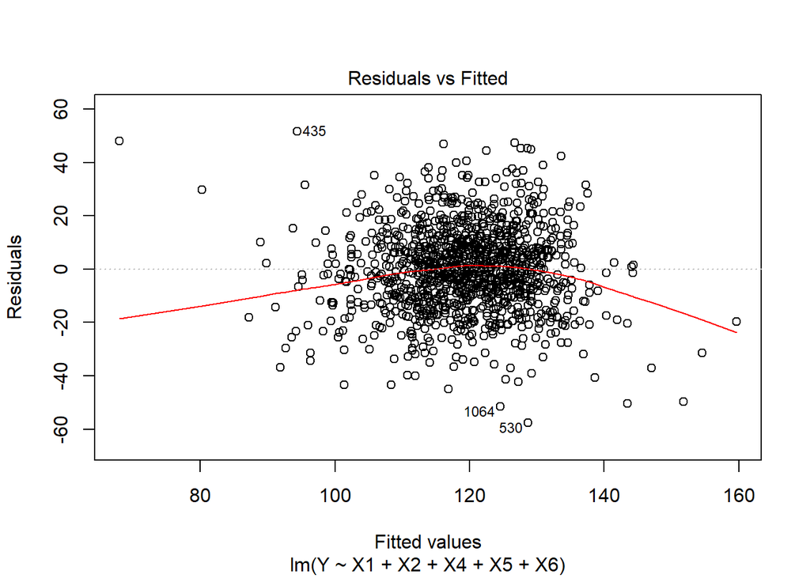

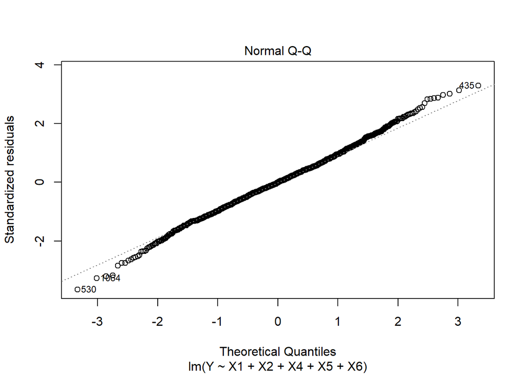

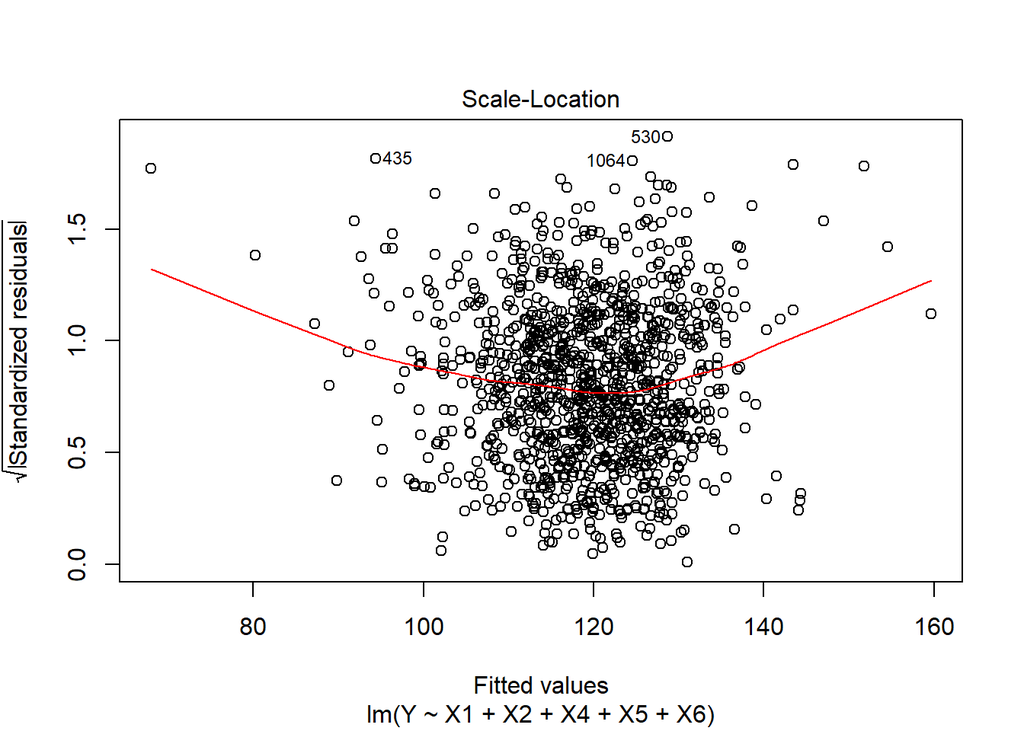

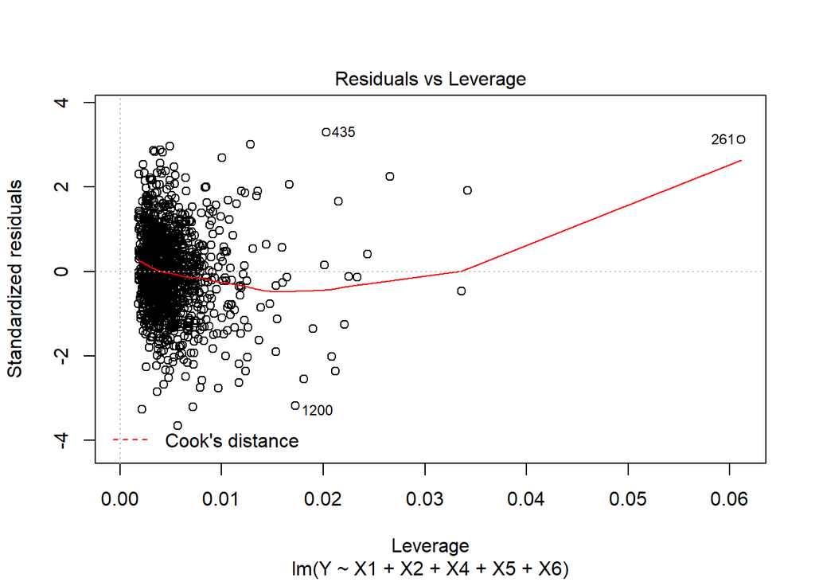

[output not shown]

```r
plot(rm_X3.lm)
```

3. In the plots you created before doing any regressions, there were apparent outliers with regard to both X1 and X4. Without doing the work, say what steps you would take to evaluate whether we should consider removing these outliers. (Your own comment box.)

```
review the plot() of the regression and see which values appear to be outliers in the QQ and residual. Then create a subset of the data removing those outliers.

Could also conduct t-tests to check if outlier is significant from the majority of the data.
```

4. Using `Forward Addition`, choose a “best” multilinear model for this data set. Begin by choosing the single predictor that gives the highest value of Adjusted R-squared and continue by adding variables until Adjusted R-squared has been maximized. *Your answer should consist of a set of nested models with increasing Adjusted R-squared*

```r
#X1- 0.1654 *
#X2- 0.001076
#X3- -0.0001245
#X4- 0.04068
#X5- 0.02348
#x6- 0.06011

x1.lm <- lm(Y ~  X1, data=bbycomp)
summary(x1.lm)
```

```
##
## Call:
## lm(formula = Y ~ X1, data = bbycomp)
##
## Residuals:
##     Min      1Q  Median      3Q     Max
## -49.348 -11.065   0.218  10.101  57.704
##
## Coefficients:
##              Estimate Std. Error t value Pr(>|t|)
## (Intercept) -10.75414    8.53693   -1.26    0.208
## X1            0.46656    0.03054   15.28   <2e-16 ***
## ---
## Signif. codes:  0 '***' 0.001 '**' 0.01 '*' 0.05 '.' 0.1 ' ' 1
##
## Residual standard error: 16.74 on 1172 degrees of freedom
## Multiple R-squared:  0.1661, Adjusted R-squared:  0.1654
## F-statistic: 233.4 on 1 and 1172 DF,  p-value: < 2.2e-16
```

```r
#0.1654
#X2- 0.1706
#X3- 0.1671
#X4- 0.1955
#X5- 0.1861
#x6- 0.2143 *


x1_6.lm <- lm(Y ~  X1 + X6, data=bbycomp)
summary(x1_6.lm)
```

```
##
## Call:
## lm(formula = Y ~ X1 + X6, data = bbycomp)
##
## Residuals:
##     Min      1Q  Median      3Q     Max
## -50.789 -11.035  -0.211  10.053  52.412
##
## Coefficients:
##             Estimate Std. Error t value Pr(>|t|)
## (Intercept) -3.18492    8.32945  -0.382    0.702
## X1           0.45117    0.02968  15.200   <2e-16 ***
## X6          -8.37440    0.97346  -8.603   <2e-16 ***
## ---
## Signif. codes:  0 '***' 0.001 '**' 0.01 '*' 0.05 '.' 0.1 ' ' 1
##
## Residual standard error: 16.25 on 1171 degrees of freedom
## Multiple R-squared:  0.2157, Adjusted R-squared:  0.2143
## F-statistic:   161 on 2 and 1171 DF,  p-value: < 2.2e-16
```

```r
#0.2143

#X2- 0.2198
#X3- 0.2147
#X4- 0.2463 *
#X5- 0.2315

x1_6_4.lm <- lm(Y ~  X1 + X6 + X4, data=bbycomp)
summary(x1_6_4.lm)
```

```
##
## Call:
## lm(formula = Y ~ X1 + X6 + X4, data = bbycomp)
##
## Residuals:
##     Min      1Q  Median      3Q     Max
## -57.373 -10.365  -0.450   9.853  53.250
##
## Coefficients:
##              Estimate Std. Error t value Pr(>|t|)
## (Intercept) -83.01125   13.87372  -5.983 2.90e-09 ***
## X1            0.43631    0.02915  14.969  < 2e-16 ***
## X6           -8.52262    0.95370  -8.936  < 2e-16 ***
## X4            1.31198    0.18443   7.114 1.96e-12 ***
## ---
## Signif. codes:  0 '***' 0.001 '**' 0.01 '*' 0.05 '.' 0.1 ' ' 1
##
## Residual standard error: 15.91 on 1170 degrees of freedom
## Multiple R-squared:  0.2482, Adjusted R-squared:  0.2463
## F-statistic: 128.7 on 3 and 1170 DF,  p-value: < 2.2e-16
```

```r
#0.2463

#X2- 0.2529 *
#X3- 0.2467
#X5- 0.2493

x1_6_4_2.lm <- lm(Y ~  X1 + X6 + X4 + X2, data=bbycomp)
summary(x1_6_4_2.lm)
```

```
##
## Call:
## lm(formula = Y ~ X1 + X6 + X4 + X2, data = bbycomp)
##
## Residuals:
##     Min      1Q  Median      3Q     Max
## -58.415 -10.173  -0.094   9.835  52.711
##
## Coefficients:
##              Estimate Std. Error t value Pr(>|t|)
## (Intercept) -85.71342   13.83578  -6.195 8.06e-10 ***
## X1            0.44393    0.02911  15.252  < 2e-16 ***
## X6           -8.54051    0.94951  -8.995  < 2e-16 ***
## X4            1.33565    0.18375   7.269 6.62e-13 ***
## X2           -3.56015    1.05529  -3.374 0.000766 ***
## ---
## Signif. codes:  0 '***' 0.001 '**' 0.01 '*' 0.05 '.' 0.1 ' ' 1
##
## Residual standard error: 15.84 on 1169 degrees of freedom
## Multiple R-squared:  0.2554, Adjusted R-squared:  0.2529
## F-statistic: 100.3 on 4 and 1169 DF,  p-value: < 2.2e-16
```

```r
x1_6_4_2_5.lm <- lm(Y ~  X1 + X6 + X4 + X2 + X5, data=bbycomp)
summary(x1_6_4_2_5.lm)
```

```
##
## Call:
## lm(formula = Y ~ X1 + X6 + X4 + X2 + X5, data = bbycomp)
##
## Residuals:
##     Min      1Q  Median      3Q     Max
## -57.716 -10.150  -0.159   9.689  51.620
##
## Coefficients:
##              Estimate Std. Error t value Pr(>|t|)
## (Intercept) -80.71321   14.04465  -5.747 1.16e-08 ***
## X1            0.44408    0.02907  15.276  < 2e-16 ***
## X6           -8.39390    0.95117  -8.825  < 2e-16 ***
## X4            1.15497    0.20473   5.641 2.11e-08 ***
## X2           -3.28762    1.06281  -3.093  0.00203 **
## X5            0.04983    0.02503   1.991  0.04672 *
## ---
## Signif. codes:  0 '***' 0.001 '**' 0.01 '*' 0.05 '.' 0.1 ' ' 1
##
## Residual standard error: 15.82 on 1168 degrees of freedom
## Multiple R-squared:  0.2579, Adjusted R-squared:  0.2548
## F-statistic:  81.2 on 5 and 1168 DF,  p-value: < 2.2e-16
```

5. For the sequence of nested models above, conduct an ANOVA test comparing each model to the previous, reduced model to see if the new coefficient is statistically different from zero compared to the reduced model. Show the code for each test and state the results.

```r
anova(x1.lm,x1_6.lm)
```

```
## Analysis of Variance Table
##
## Model 1: Y ~ X1
## Model 2: Y ~ X1 + X6
##   Res.Df    RSS Df Sum of Sq      F    Pr(>F)
## 1   1172 328608
## 2   1171 309075  1     19533 74.007 < 2.2e-16 ***
## ---
## Signif. codes:  0 '***' 0.001 '**' 0.01 '*' 0.05 '.' 0.1 ' ' 1
```

```r
anova(x1_6.lm,x1_6_4.lm)
```

```
## Analysis of Variance Table
##
## Model 1: Y ~ X1 + X6
## Model 2: Y ~ X1 + X6 + X4
##   Res.Df    RSS Df Sum of Sq      F    Pr(>F)
## 1   1171 309075
## 2   1170 296261  1     12814 50.605 1.963e-12 ***
## ---
## Signif. codes:  0 '***' 0.001 '**' 0.01 '*' 0.05 '.' 0.1 ' ' 1
```

```r
anova(x1_6_4.lm,x1_6_4_2.lm)
```

```
## Analysis of Variance Table
##
## Model 1: Y ~ X1 + X6 + X4
## Model 2: Y ~ X1 + X6 + X4 + X2
##   Res.Df    RSS Df Sum of Sq      F    Pr(>F)
## 1   1170 296261
## 2   1169 293404  1    2856.6 11.381 0.0007662 ***
## ---
## Signif. codes:  0 '***' 0.001 '**' 0.01 '*' 0.05 '.' 0.1 ' ' 1
```

```r
anova(x1_6_4_2.lm,x1_6_4_2_5.lm)
```

```
## Analysis of Variance Table
##
## Model 1: Y ~ X1 + X6 + X4 + X2
## Model 2: Y ~ X1 + X6 + X4 + X2 + X5
##   Res.Df    RSS Df Sum of Sq      F  Pr(>F)
## 1   1169 293404
## 2   1168 292412  1    992.37 3.9639 0.04672 *
## ---
## Signif. codes:  0 '***' 0.001 '**' 0.01 '*' 0.05 '.' 0.1 ' ' 1
```

```
The ANOVA of X1.lm and x1_6.lm had the smallest p value out of all the anova comparisons(2.2e-16 vs 1.963e-12 &0.0007662 &0.04672). ANOVA of the first comparisons closest to 0.
```

6. Would considering some interactions make sense? Try to add some interactions to the best models and see what happens.

```r
mult.own <- lm(formula = Y ~ parity+height+(gestation+smoke)^2, data = bbycomp)

summary(mult.own)
```

```
##
## Call:
## lm(formula = Y ~ parity + height + (gestation + smoke)^2, data = bbycomp)
##
## Residuals:
##     Min      1Q  Median      3Q     Max
## -58.516 -10.038   0.112   9.623  54.541
##
## Coefficients:
##                  Estimate Std. Error t value Pr(>|t|)
## (Intercept)     -63.04258   15.16020  -4.158 3.44e-05 ***
## parity           -3.54422    1.05004  -3.375 0.000762 ***
## height            1.31298    0.18294   7.177 1.26e-12 ***
## gestation         0.36810    0.03591  10.249  < 2e-16 ***
## smoke           -68.51538   16.82223  -4.073 4.96e-05 ***
## gestation:smoke   0.21528    0.06029   3.571 0.000370 ***
## ---
## Signif. codes:  0 '***' 0.001 '**' 0.01 '*' 0.05 '.' 0.1 ' ' 1
##
## Residual standard error: 15.76 on 1168 degrees of freedom
## Multiple R-squared:  0.2635, Adjusted R-squared:  0.2603
## F-statistic: 83.56 on 5 and 1168 DF,  p-value: < 2.2e-16
```

[output not shown]